# Resumen Comparativo de Modelos

Inflación (SARIMA, ARIMA, ARIMAX) y Tipo de Cambio (ARIMA)

Análisis Econométrico

22 de julio de 2026

> Resumen comparativo de los modelos ya construidos y validados en sus propios reportes (`SARIMA_Inflacion.Rmd`, `ARIMA_Inflacion.Rmd`, `ARIMAX_Inflacion.Rmd`, `ARIMA_TC.Rmd`).

# 1 Inflación — Tres Modelos

## 1.1 SARIMA (`SARIMA_Inflacion.Rmd`)

SARIMA — resumen del modelo elegido

| Criterio | Valor |
| --- | --- |
| Ganador A | (1,1,0)(1,0,0)[12] |
| Ganador B | (1,1,0)(1,0,0)[12] |
| Elegido (menor RMSE fuera de muestra) | A: (1,1,0)(1,0,0)[12] |
| RMSE / MAPE — 6 meses (IPC) | 1.3356 / 0.78% |

## 1.2 ARIMA M2 (`ARIMA_Inflacion.Rmd`)

ARIMA M2 — resumen del modelo elegido

| Criterio | Valor |
| --- | --- |
| Ganador de la grilla | ARIMA(1,1,1) |
| RMSE / MAPE — 6 meses (IPC) | 2.0664 / 1.08% |

> M2 se estima desde 2023 **sin dummies de intervención** — si la grilla elige drift, ese drift absorbe cualquier shock no modelado dentro de la ventana muestral (ver discusión en `SARIMA_Inflacion.Rmd`).

## 1.3 ARIMAX (`ARIMAX_Inflacion.Rmd`)

ARIMAX — resumen del modelo elegido

| Criterio | Valor |
| --- | --- |
| Ganador base (sin TC) | ARIMA(1,1,1) |
| Ganador +TC digital | ARIMA(1,1,1)+TC_dig |
| Elegido (menor RMSE fuera de muestra) | ARIMA(1,1,1)+TC_dig |
| RMSE / MAPE — 6 meses (IPC) | 1.7732 / 1.03% |

> El TC digital mejora el pronostico fuera de muestra en esta corrida.

## 1.4 Proyección Comparada — 6 Meses

Inflación interanual proyectada — A: (1,1,0)(1,0,0)[12] | ARIMA(1,1,1) | ARIMA(1,1,1)+TC_dig

| Mes | SARIMA (%interanual) | ARIMA M2 (%interanual) | ARIMAX (%interanual) |
| --- | --- | --- | --- |
| Julio | 8.59 | 9.65 | 9.65 |
| Agosto | 8.00 | 9.93 | 9.87 |
| Septiembre | 7.92 | 10.81 | 10.66 |
| Octubre | 7.43 | 10.87 | 10.61 |
| Noviembre | 7.18 | 11.14 | 10.76 |
| Diciembre | 6.79 | 11.05 | 10.57 |

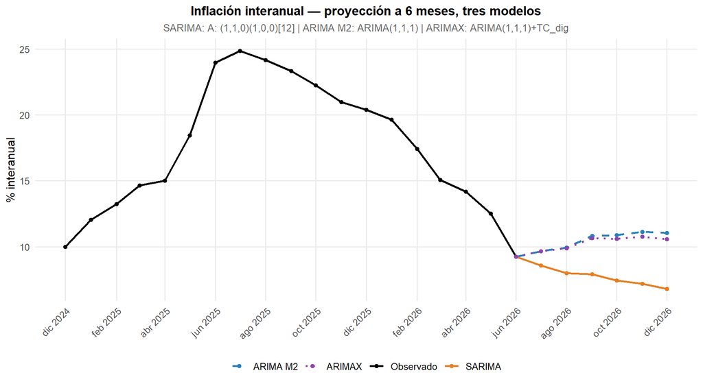